# WSP closed question analysis

Lizzie Jones[^1]

10/05/2021

## WSP - Analysis, stats and visualisations for closed questions

This rMarkdown explores and analyses the closed-ended questions

### About rMarkdowns

This rMarkdown document will be periodically updated and uploaded to the OneDrive folder and pushed to the WSP GitHub code repository. The primary format of this document is HTML, but this can be easily changed by changing the output (e.g. PDF, GitHub) using the ‘output’ section at the top of the document. The possible output formats are listed here: https://rmarkdown.rstudio.com/lesson-9.html.

### Creating our own ‘WSP’ colour palette

The following code creates a custom colour palette to be called into GGPLOT objects (similar to rColourBrewer palettes). The colour scheme is based on the colours used for the Likert package for continuity in the manuscript.

```r
## Creating a custom colour palette
theme_set(theme_minimal())
wsp_colors <- c(
  `turquoise`  = "#5ab4ac",
  `light_tur`  = "#acd9d5",
  `grey`       = "#e5e5e5",
  `light_gold` = "#ebd9b2",
  `gold`       = "#d8b365")

wsp_cols <- function(...) {
  cols <- c(...)

  if (is.null(cols))
    return (wsp_colors)

  wsp_colors[cols]
}

# Test the code and see the colours
wsp_cols()
```

```
##  turquoise  light_tur       grey light_gold       gold
##  "#5ab4ac"  "#acd9d5"  "#e5e5e5"  "#ebd9b2"  "#d8b365"
```

```r
# Create two custom palettes using the wsp_cols()called 'likert' and 'light'
wsp_palettes <- list(

  `likert`  = wsp_cols("turquoise", "light_tur", "grey", "light_gold", "gold"),

  `light`  = wsp_cols("light_tur", "grey", "light_gold")
)

# A function to access and interpolate
wsp_pal <- function(palette = "likert", reverse = FALSE, ...) {
  pal <- wsp_palettes[[palette]]

  if (reverse) pal <- rev(pal)

  colorRampPalette(pal, ...)
}
# Check the 5-colour palette
wsp_pal("light")(10)
```

```
##  [1] "#ACD9D5" "#B8DBD8" "#C5DEDC" "#D2E1DF" "#DEE3E3" "#E5E3DF" "#E7E1D4"
##  [8] "#E8DEC8" "#E9DBBD" "#EBD9B2"
```

```r
### Scales for ggplot2 plots - either fill (for geom_bar etc.) or colour (for geom_point etc.)
## COLOUR
scale_color_wsp <- function(palette = "likert", discrete = TRUE, reverse = FALSE, ...) {
  pal <- wsp_pal(palette = palette, reverse = reverse)

  if (discrete) {
    discrete_scale("colour", paste0("wsp_", palette), palette = pal, ...)
  } else {
    scale_color_gradientn(colours = pal(256), ...)
  }
}

## FILL
scale_fill_wsp <- function(palette = "likert", discrete = TRUE, reverse = FALSE, ...) {
  pal <- wsp_pal(palette = palette, reverse = reverse)

  if (discrete) {
    discrete_scale("fill", paste0("wsp_", palette), palette = pal, ...)
  } else {
    scale_fill_gradientn(colours = pal(256), ...)
  }
}
```

## Sectioned analysis (in order found in questionnaire)

### Respondent knowledge

Respondent knowledge questions have yes/no/notsure or incorrect/correct answer formats, lending themselves to Likert or Stacked bar plot style plots. Below I have created summary statistics and plots, seperated according to locality for this rMarkdown (using the Proactive sample only) but the code is also there to seperate according to survey type, but is hashed out for brevity using #. The summary statistics calculate sample sizes per question to create a table to display the sample sizes per column, per survey type.

Some useful Likert plotting guides and packages: * https://cran.r-project.org/web/packages/sjPlot/vignettes/plot_likert_scales.html * https://towardsdatascience.com/how-to-plot-likert-scales-with-a-weighted-survey-in-a-dplyr-friendly-way-68df600881a * https://www.r-graph-gallery.com/202-barplot-for-likert-type-items.html

### Q1) Had you heard of a white stork before taking this survey?

```r
# # By Survey type
# final_data %>%
#   dplyr::select(SurveyType, Q1_aware_stork) %>%
#   dplyr::group_by(SurveyType, Q1_aware_stork) %>%
#   summarise(n = n()) %>%
#   mutate(Percent = (n / sum(n)*100))


# By locality within Proactive
proact_data %>%
  dplyr::select(SiteLocal, Q1_aware_stork) %>%
  dplyr::group_by(SiteLocal, Q1_aware_stork) %>%
  summarise(n = n()) %>%
  mutate(Percent = (n / sum(n)*100))
```

```
## # A tibble: 4 x 4
## # Groups:   SiteLocal [2]
##   SiteLocal Q1_aware_stork     n Percent
##   <fct>     <fct>          <int>   <dbl>
## 1 Local     No                84    8.28
## 2 Local     Yes              930   91.7
## 3 Not local No               104    7.57
## 4 Not local Yes             1270   92.4
```

### Q2) Which of the following animals is a white stork?

```r
# # By sample
# final_data %>%
#   dplyr::select(SurveyType, Q2_photo_recog_score, Q2_photo_recog) %>%
#   dplyr::group_by(SurveyType, Q2_photo_recog) %>%
#   summarise(n = n()) %>%
#   mutate(Percent = (n / sum(n)*100))


# By locality within PROACTIVE
proact_data %>%
  dplyr::select(SiteLocal, Q2_photo_recog_score, Q2_photo_recog) %>%
  dplyr::group_by(SiteLocal, Q2_photo_recog) %>%
  summarise(n = n()) %>%
  mutate(Percent = (n / sum(n)*100))
```

```
## # A tibble: 12 x 4
## # Groups:   SiteLocal [2]
##    SiteLocal Q2_photo_recog     n Percent
##    <fct>     <fct>          <int>   <dbl>
##  1 Local     A                  8  0.789
##  2 Local     B                883 87.1
##  3 Local     C                  3  0.296
##  4 Local     D                 92  9.07
##  5 Local     Don't know        27  2.66
##  6 Local     E                  1  0.0986
##  7 Not local A                  8  0.582
##  8 Not local B               1241 90.3
##  9 Not local C                  3  0.218
## 10 Not local D                 79  5.75
## 11 Not local Don't know        42  3.06
## 12 Not local E                  1  0.0728
```

### Q3) Is the white stork native to England?

```
## # A tibble: 6 x 4
## # Groups:   SiteLocal [2]
##   SiteLocal Q3_is_native     n Percent
##   <fct>     <fct>        <int>   <dbl>
## 1 Local     No             172    17.0
## 2 Local     Not sure       324    32.0
## 3 Local     Yes            518    51.1
## 4 Not local No             172    12.5
## 5 Not local Not sure       358    26.1
## 6 Not local Yes            844    61.4
```

### Q4) Are the following statements true or false?

1. Most European white storks migrate south to Africa in the winter
2. A white stork’s wingspan can exceed 2 meters (6 feet 7 inches)
3. White storks are globally rare

```
## # A tibble: 6 x 4
## # Groups:   SiteLocal [2]
##   SiteLocal Q4.1_migrate     n Percent
##   <fct>     <fct>        <int>   <dbl>
## 1 Local     Don't know     394   38.9
## 2 Local     FALSE           45    4.44
## 3 Local     TRUE           575   56.7
## 4 Not local Don't know     467   34.0
## 5 Not local FALSE           48    3.49
## 6 Not local TRUE           859   62.5
```

```
## # A tibble: 6 x 4
## # Groups:   SiteLocal [2]
##   SiteLocal Q4.2_wingspan     n Percent
##   <fct>     <fct>         <int>   <dbl>
## 1 Local     Don't know      264   26.0
## 2 Local     FALSE            34    3.35
## 3 Local     TRUE            716   70.6
## 4 Not local Don't know      354   25.8
## 5 Not local FALSE            48    3.49
## 6 Not local TRUE            972   70.7
```

```
## # A tibble: 6 x 4
## # Groups:   SiteLocal [2]
##   SiteLocal Q4.3_globallyrare     n Percent
##   <fct>     <fct>             <int>   <dbl>
## 1 Local     Don't know          451    44.5
## 2 Local     FALSE               235    23.2
## 3 Local     TRUE                328    32.3
## 4 Not local Don't know          585    42.6
## 5 Not local FALSE               462    33.6
## 6 Not local TRUE                327    23.8
```

### Q5) What do white storks typically eat?

[multi-select] Amphibians; Fish; Invertebrates; Reptiles; Small mammals; Bird eggs/chicks; Carrion; Food waste; Vegetation; Seeds; Fruit; Don’t know

```
##   Q5a_amphibians_diet Q5b_birdeggs.chicks_diet Q5c_carrion_diet Q5d_fish_diet
## 1           Incorrect                Incorrect        Incorrect       Correct
## 2           Incorrect                Incorrect        Incorrect     Incorrect
## 3             Correct                Incorrect        Incorrect       Correct
## 4             Correct                  Correct        Incorrect       Correct
## 5             Correct                Incorrect        Incorrect     Incorrect
## 6           Incorrect                Incorrect        Incorrect     Incorrect
##   Q5e_foodwaste_diet Q5f_fruit_diet Q5g_inverts_diet Q5h_reptiles_diet
## 1          Incorrect        Correct          Correct         Incorrect
## 2          Incorrect      Incorrect        Incorrect         Incorrect
## 3          Incorrect      Incorrect          Correct           Correct
## 4          Incorrect      Incorrect          Correct           Correct
## 5          Incorrect      Incorrect          Correct           Correct
## 6          Incorrect      Incorrect        Incorrect         Incorrect
##   Q5i_seeds_diet Q5j_smallmammals_diet Q5k_vegetation_diet Q5l_Don.tKnow_diet
## 1        Correct             Incorrect           Incorrect          Incorrect
## 2      Incorrect             Incorrect           Incorrect            Correct
## 3      Incorrect               Correct           Incorrect          Incorrect
## 4        Correct               Correct           Incorrect          Incorrect
## 5      Incorrect               Correct           Incorrect          Incorrect
## 6      Incorrect             Incorrect           Incorrect            Correct
```

```
## # A tibble: 24 x 5
## # Groups:   SiteLocal, Diet [24]
##    SiteLocal Diet                     Answer  count percent
##    <fct>     <chr>                    <chr>   <int>   <dbl>
##  1 Local     Q5a_amphibians_diet      Correct   525   51.8
##  2 Local     Q5b_birdeggs.chicks_diet Correct   222   21.9
##  3 Local     Q5c_carrion_diet         Correct    97    9.57
##  4 Local     Q5d_fish_diet            Correct   554   54.6
##  5 Local     Q5e_foodwaste_diet       Correct    83    8.19
##  6 Local     Q5f_fruit_diet           Correct    67    6.61
##  7 Local     Q5g_inverts_diet         Correct   507   50
##  8 Local     Q5h_reptiles_diet        Correct   307   30.3
##  9 Local     Q5i_seeds_diet           Correct    82    8.09
## 10 Local     Q5j_smallmammals_diet    Correct   291   28.7
## # … with 14 more rows
```

### Q6) What are white storks preferred feeding habitat?

[multi-select] Shallow wetlands; Grassland; Farmland; Woodland; Urban; Don’t know

```
## # A tibble: 12 x 5
## # Groups:   SiteLocal, Habitat [12]
##    SiteLocal Habitat               Answer count percent
##    <fct>     <chr>                 <chr>  <int>   <dbl>
##  1 Local     Q6a_farmland_habitat  Yes      275   27.1
##  2 Local     Q6b_grassland_habitat Yes      477   47.0
##  3 Local     Q6c_wetlands_habitat  Yes      654   64.5
##  4 Local     Q6d_woodland_habitat  Yes      120   11.8
##  5 Local     Q6e_urban_habitat     Yes       32    3.16
##  6 Local     Q6f_Don.tKnow_habitat Yes      162   16.0
##  7 Not local Q6a_farmland_habitat  Yes      437   31.8
##  8 Not local Q6b_grassland_habitat Yes      682   49.6
##  9 Not local Q6c_wetlands_habitat  Yes     1009   73.4
## 10 Not local Q6d_woodland_habitat  Yes       86    6.26
## 11 Not local Q6e_urban_habitat     Yes       52    3.78
## 12 Not local Q6f_Don.tKnow_habitat Yes      201   14.6
```

### Q7) Where do white storks typically nest?

[multi-select] Trees; Roofs of buildings; Chimneys; Telegraph poles; Ground; Don’t know

```
## # A tibble: 12 x 5
## # Groups:   SiteLocal, Nest [12]
##    SiteLocal Nest                       Answer count percent
##    <fct>     <chr>                      <chr>  <int>   <dbl>
##  1 Local     Q7a_chimneys_nesting       Yes      462   45.6
##  2 Local     Q7b_ground_nesting         Yes       47    4.64
##  3 Local     Q7c_roofs_nesting          Yes      467   46.1
##  4 Local     Q7d_telegraphpoles_nesting Yes      344   33.9
##  5 Local     Q7e_trees_nesting          Yes      764   75.3
##  6 Local     Q7f_Don.tKnow_nesting      Yes       84    8.28
##  7 Not local Q7a_chimneys_nesting       Yes      789   57.4
##  8 Not local Q7b_ground_nesting         Yes       59    4.29
##  9 Not local Q7c_roofs_nesting          Yes      785   57.1
## 10 Not local Q7d_telegraphpoles_nesting Yes      634   46.1
## 11 Not local Q7e_trees_nesting          Yes     1020   74.2
## 12 Not local Q7f_Don.tKnow_nesting      Yes      116    8.44
```

## If/where seen a white stork

### Q8) Before taking this survey, had you ever seen a white stork?

[multi-select] Yes, in the wild; Yes, in captivity; Yes, in pictures/videos; No; Not sure

```
## # A tibble: 11 x 5
## # Groups:   SiteLocal, Q8_option [11]
##    SiteLocal Q8_option         Answer     n Percent
##    <fct>     <chr>              <int> <int>   <dbl>
##  1 Local     Q8_captivity_seen      1   121 11.9
##  2 Local     Q8_No                  1   160 15.8
##  3 Local     Q8_NotSure             1    50  4.93
##  4 Local     Q8_pictures_video      1   298 29.4
##  5 Local     Q8_wild_seen           1   562 55.4
##  6 Local     UniqueID_all           1     1  0.0986
##  7 Not local Q8_captivity_seen      1   246 17.9
##  8 Not local Q8_No                  1   179 13.0
##  9 Not local Q8_NotSure             1    69  5.02
## 10 Not local Q8_pictures_video      1   529 38.5
## 11 Not local Q8_wild_seen           1   724 52.7
```

```
## # A tibble: 8 x 4
## # Groups:   SiteLocal [2]
##   SiteLocal Q8.WhereSeen     n Percent
##   <fct>     <fct>        <int>   <dbl>
## 1 Local     Both           108    10.7
## 2 Local     OutsideUK      181    17.9
## 3 Local     UK             273    26.9
## 4 Local     <NA>           452    44.6
## 5 Not local Both           181    13.2
## 6 Not local OutsideUK      398    29.0
## 7 Not local UK             145    10.6
## 8 Not local <NA>           650    47.3
```

### Q9) Before taking this survey, had you ever heard of the White Stork Project and its efforts to reintroduce white storks to southern England?

[options] Yes, No, Not sure

```
## # A tibble: 6 x 4
## # Groups:   SiteLocal [2]
##   SiteLocal Q9_heard     n Percent
##   <fct>     <fct>    <int>   <dbl>
## 1 Local     No         292   28.8
## 2 Local     Not sure    26    2.56
## 3 Local     Yes        696   68.6
## 4 Not local No         381   27.7
## 5 Not local Not sure    43    3.13
## 6 Not local Yes        950   69.1
```

### Q10) How much do you feel you know about the white stork reintroduction currently taking place in southern England?

Nothing; I have heard something but don’t know much; I know something about it; I know a lot about it; I am involved in the effort

```
## # A tibble: 11 x 4
## # Groups:   SiteLocal [2]
##    SiteLocal Q10_project_knowledge                          n Percent
##    <fct>     <fct>                                      <int>   <dbl>
##  1 Local     I am involved in the effort                   12   1.18
##  2 Local     I have heard something but don’t know much   315  31.1
##  3 Local     I know a lot about it                         74   7.30
##  4 Local     I know something about it                    374  36.9
##  5 Local     Nothing                                      239  23.6
##  6 Not local I am involved in the effort                    3   0.218
##  7 Not local I have heard something but don’t know much   414  30.1
##  8 Not local I know a lot about it                         96   6.99
##  9 Not local I know something about it                    532  38.7
## 10 Not local Nothing                                      327  23.8
## 11 Not local <NA>                                           2   0.146
```

### Q10a) [if selected any option apart from “Nothing”] Where have you heard about the white stork reintroduction project?

[multi-select] White Stork Project website; Social media; TV/Radio; Newspaper; Email; Magazine; Leaflet; Talk by a project spokesperson; Visiting Knepp Estate; Word of mouth; Other

```
## # A tibble: 23 x 5
## # Groups:   SurveyType, Q10_cursource [23]
##    SurveyType Q10_cursource      Answer     n Percent
##    <fct>      <chr>              <chr>  <int>   <dbl>
##  1 NatRep     Q10a_Email         1         18    6.87
##  2 NatRep     Q10a_Leaflet       1         12    4.58
##  3 NatRep     Q10a_Magazine      1         32   12.2
##  4 NatRep     Q10a_Newspaper     1         45   17.2
##  5 NatRep     Q10a_Other         1         12    4.58
##  6 NatRep     Q10a_Socialmedia   1         66   25.2
##  7 NatRep     Q10a_spokesperson  1          7    2.67
##  8 NatRep     Q10a_TV.Radio      1         82   31.3
##  9 NatRep     Q10a_VisitingKnepp 1          5    1.91
## 10 NatRep     Q10a_Wordofmouth   1         36   13.7
## # … with 13 more rows
```

### Q10b) How would you like information about the ongoing reintroduction to be communicated to you?

[multi-select] White Stork Project website; Social media; TV/Radio; Newspaper; Email; Magazine; Leaflet; Talk by a project spokesperson; Not interested; Other

```
## # A tibble: 20 x 5
## # Groups:   SiteLocal, Q10_pref [20]
##    SiteLocal Q10_pref       Answer     n Percent
##    <fct>     <chr>          <chr>  <int>   <dbl>
##  1 Local     Email          1        342   33.1
##  2 Local     Leaflet        1         71    6.88
##  3 Local     Magazine       1        123   11.9
##  4 Local     Newspaper      1        208   20.2
##  5 Local     Not interested 1         51    4.94
##  6 Local     Other          1         12    1.16
##  7 Local     Social media   1        601   58.2
##  8 Local     Spokesperson   1        172   16.7
##  9 Local     TV or radio    1        372   36.0
## 10 Local     WSP website    1        567   54.9
## 11 Not local Email          1        783   31.3
## 12 Not local Leaflet        1        232    9.28
## 13 Not local Magazine       1        315   12.6
## 14 Not local Newspaper      1        498   19.9
## 15 Not local Not interested 1        257   10.3
## 16 Not local Other          1         25    1.00
## 17 Not local Social media   1       1260   50.4
## 18 Not local Spokesperson   1        345   13.8
## 19 Not local TV or radio    1        894   35.8
## 20 Not local WSP website    1       1219   48.8
```

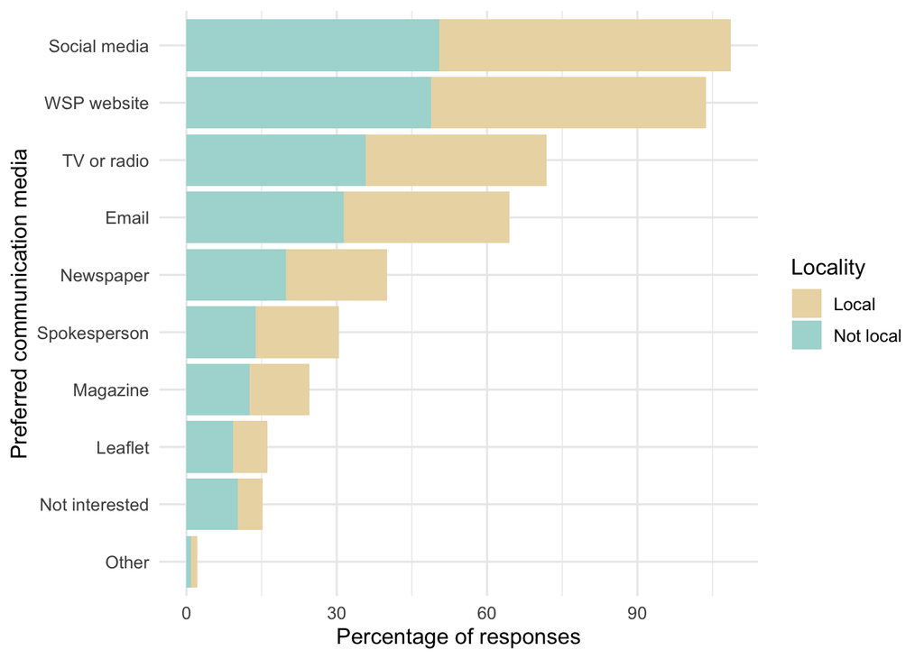

### Q12-14) How much do you agree or disagree with the following statements?

- White storks symbolise the beauty of nature.
- White storks play an important role in their environment.
- Reintroduced white storks may have a negative impact on my life.
- I do not want white storks living near me.
- White storks in England could benefit the tourism industry where they’re found.
- I would find it exciting to see white storks in the wild in England.
- White storks symbolise hope, rebirth and new life.
- Money spent reintroducing white storks would be better spent elsewhere.
- White storks might be detrimental to local wildlife.
- There is no need to reintroduce the white stork to England as it is common throughout mainland Europe
- I think white storks are useless birds.
- White storks are part of our cultural and natural heritage
- The reintroduced white stork can help people (re)connect with the natural world.
- The countryside will be worse off with white storks around.
- Overall, I support efforts that aim to reintroduce the UK’s lost species and restore its natural systems.

```
## # A tibble: 3,699 x 5
## # Groups:   SurveyType, Attitude_questions [30]
##    SurveyType Attitude_questions                       Answer          n Percent
##    <fct>      <chr>                                    <chr>       <int>   <dbl>
##  1 NatRep     Q12.1..White.storks.symbolise.the.beaut… Agree         479   41.9
##  2 NatRep     Q12.1..White.storks.symbolise.the.beaut… Disagree       21    1.84
##  3 NatRep     Q12.1..White.storks.symbolise.the.beaut… Don't know     42    3.67
##  4 NatRep     Q12.1..White.storks.symbolise.the.beaut… Neutral       223   19.5
##  5 NatRep     Q12.1..White.storks.symbolise.the.beaut… Strongly a…   354   31.0
##  6 NatRep     Q12.1..White.storks.symbolise.the.beaut… Strongly d…    24    2.10
##  7 NatRep     Q12.2..White.storks.play.an.important.r… Agree         437   38.2
##  8 NatRep     Q12.2..White.storks.play.an.important.r… Disagree       22    1.92
##  9 NatRep     Q12.2..White.storks.play.an.important.r… Don't know    180   15.7
## 10 NatRep     Q12.2..White.storks.play.an.important.r… Neutral       238   20.8
## # … with 3,689 more rows
```

### Q15. Do you support the reintroduction of white storks to southern England?

[single-option] Yes; No; Not sure

```
## # A tibble: 6 x 5
## # Groups:   SurveyType, Support [2]
##   SurveyType Support         Answer       n Percent
##   <fct>      <chr>           <chr>    <int>   <dbl>
## 1 NatRep     Q15_WSP_support No          49    4.29
## 2 NatRep     Q15_WSP_support Not sure   239   20.9
## 3 NatRep     Q15_WSP_support Yes        855   74.8
## 4 Proactive  Q15_WSP_support No          86    3.60
## 5 Proactive  Q15_WSP_support Not sure   125    5.23
## 6 Proactive  Q15_WSP_support Yes       2177   91.2
```

### Q16a. Expressing views on WS management

[single-option] Yes; No; Not sure; Not interested

```
##   Q16_views_management
## 1                   No
## 2                   No
## 3             Not sure
## 4                  Yes
## 5             Not sure
## 6                   No
```

```
## # A tibble: 12 x 5
## # Groups:   SurveyType, Management_view [4]
##    SurveyType Management_view      Answer             n Percent
##    <fct>      <chr>                <chr>          <int>   <dbl>
##  1 NatRep     Q16_views_management No               348   30.4
##  2 NatRep     Q16_views_management Not interested   138   12.1
##  3 NatRep     Q16_views_management Not sure         542   47.4
##  4 NatRep     Q16_views_management Yes              115   10.1
##  5 NatRep     SiteLocal            Local             18    1.57
##  6 NatRep     SiteLocal            Not local       1125   98.4
##  7 Proactive  Q16_views_management No               722   30.2
##  8 Proactive  Q16_views_management Not interested   134    5.61
##  9 Proactive  Q16_views_management Not sure        1243   52.1
## 10 Proactive  Q16_views_management Yes              289   12.1
## 11 Proactive  SiteLocal            Local           1014   42.5
## 12 Proactive  SiteLocal            Not local       1374   57.5
```

### Q17) Which (if any) methods of white stork project management would you support?

[multi-select] Monitoring nests; Providing places for storks to nest; Discouraging nest building; Nest removal; Tracking movements of individual storks;Public engagement and outreach; Providing supplementary food; Compensation for damage caused by stork activity; Population management by moving storks to other locations; Population management by culling; No management will be necessary; Don’t know; Other

```
##   Q17.1_Nest_monitoring Q17.2_Nesting_platforms Q17.3_Discouragenestbuilding
## 1                     1                       1                            0
## 2                     0                       0                            0
## 3                     1                       1                            0
## 4                     1                       1                            0
## 5                     1                       1                            1
## 6                     0                       0                            0
##   Q17.4_Nest_removal Q17.5_Tracking Q17.6_Public_engagement
## 1                  0              1                       1
## 2                  0              0                       0
## 3                  0              1                       1
## 4                  0              1                       1
## 5                  0              1                       1
## 6                  0              0                       0
##   Q17.7_Supplementary_food Q17.8_compensation_storkdamage
```

[output cut: 20 more lines]

```
## [1] 3531
```

```
## # A tibble: 142 x 5
## # Groups:   County, Management_options [142]
##    County Management_options           Answer     n Percent
##    <fct>  <chr>                         <int> <int>   <dbl>
##  1 ""     Q17_11.management.not.needed      1    50   1.42
##  2 ""     Q17.1_Nest_monitoring             1   743  21.0
##  3 ""     Q17.10_Culling                    1    70   1.98
##  4 ""     Q17.12_Don.tknow                  1    60   1.70
##  5 ""     Q17.13_other                      1    17   0.481
##  6 ""     Q17.2_Nesting_platforms           1   718  20.3
##  7 ""     Q17.3_Discouragenestbuilding      1   152   4.30
##  8 ""     Q17.4_Nest_removal                1    84   2.38
##  9 ""     Q17.5_Tracking                    1   681  19.3
## 10 ""     Q17.6_Public_engagement           1   697  19.7
## # … with 132 more rows
```

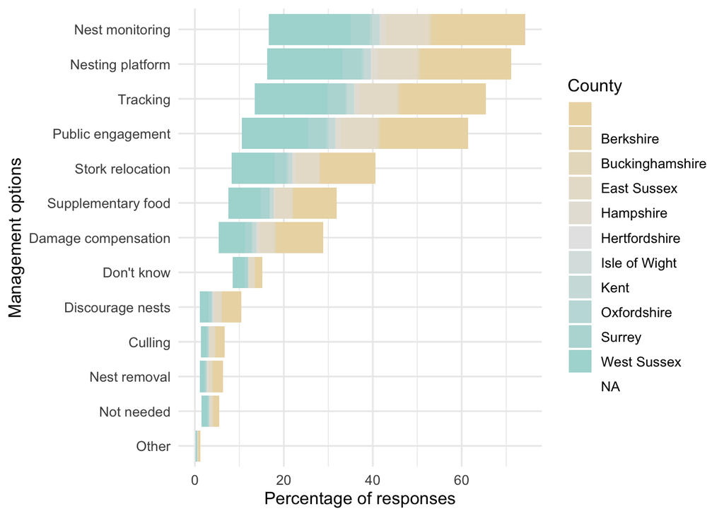

### Q18) In an average week, how many days do you spend more than 1 hour outside in green and natural spaces?

[options] None; 1-2 days; 3-4 days; 5-6 days; Every day - 7 days

```
## # A tibble: 10 x 5
## # Groups:   SurveyType, Frequency [2]
##    SurveyType Frequency                      Answer                n Percent
##    <fct>      <chr>                          <chr>             <int>   <dbl>
##  1 NatRep     Frequency of nature experience 1-2 days            459   40.2
##  2 NatRep     Frequency of nature experience 3-4 days            236   20.6
##  3 NatRep     Frequency of nature experience 5-6 days            133   11.6
##  4 NatRep     Frequency of nature experience Every day, 7 days   125   10.9
##  5 NatRep     Frequency of nature experience None                190   16.6
##  6 Proactive  Frequency of nature experience 1-2 days            523   21.9
##  7 Proactive  Frequency of nature experience 3-4 days            612   25.6
##  8 Proactive  Frequency of nature experience 5-6 days            495   20.7
##  9 Proactive  Frequency of nature experience Every day, 7 days   721   30.2
## 10 Proactive  Frequency of nature experience None                 37    1.55
```

### Q18a) Which of these recreation activities do you do while you are outside in green and natural spaces?

[multi-select] Walking (with dog); Walking (without dog); Running/cycling; Golf; Picnic; Horse riding; Bird/wildlife watching; Photography; Camping; Fishing; Shooting/hunting; Water sports/swimming; Gardening; I don’t spend my free time in green and natural spaces; Other

```
##   Q18a.golf Q18a.picnic Q18a.horse.riding Q18a.bird.wildlife.watching
## 1         0           0                 0                           0
## 2         0           1                 0                           1
## 3         0           0                 0                           1
## 4         0           0                 0                           1
## 5         0           0                 0                           1
## 6         0           1                 0                           0
##   Q18a.photography Q18a.camping Q18a.fishing Q18a.shooting.hunting
## 1                0            0            0                     0
## 2                0            0            0                     0
## 3                0            0            0                     0
## 4                0            0            0                     0
## 5                1            0            0                     0
## 6                0            0            0                     0
##   Q18a.water.sports.swimming Q18a.gardening
## 1                          0              0
## 2                          0              1
## 3                          0              0
## 4                          0              1
## 5                          0              1
## 6                          0              1
##   Q18a.don.t.spend.free.time.in.green.natural.spaces
## 1                                                  0
## 2                                                  0
## 3                                                  0
## 4                                                  0
## 5                                                  0
## 6                                                  0
```

```
## # A tibble: 22 x 5
## # Groups:   SurveyType, Activities [22]
##    SurveyType Activities        Answer     n Percent
##    <fct>      <chr>              <int> <int>   <dbl>
##  1 NatRep     Wildlife watching      1   176   15.4
##  2 NatRep     Camping                1    70    6.12
##  3 NatRep     I don't                1    90    7.87
##  4 NatRep     Fishing                1    49    4.29
##  5 NatRep     Gardening              1   444   38.8
##  6 NatRep     Golf                   1    47    4.11
##  7 NatRep     Horse riding           1    17    1.49
##  8 NatRep     Photography            1   177   15.5
##  9 NatRep     Picnic                 1   156   13.6
## 10 NatRep     Shooting/hunting       1    15    1.31
## # … with 12 more rows
```

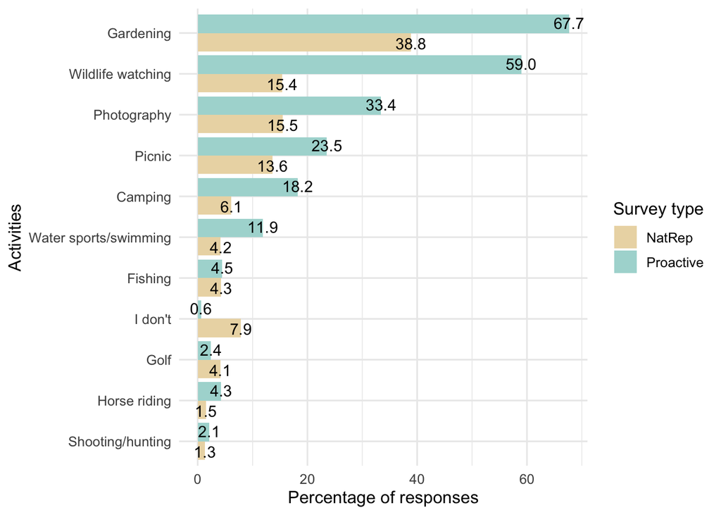

### Q19) How much do you agree or disagree with the following statements?

- I find being in nature really amazing
- Spending time in nature is very important to me
- Being in nature makes me very happy
- I always find beauty in nature
- I always treat nature with respect
- I feel part of nature

[options] Completely disagree = 1, Strongly disagree = 2, Disagree = 3, Neither agree or disagree = 4, Agree = 5, Strongly agree = 6, Completely agree = 7

```
##   Q19.1..I.find.being.in.nature.really.amazing
## 1                               Strongly agree
## 2                             Completely agree
## 3                             Completely agree
## 4                               Strongly agree
## 5                             Completely agree
## 6                               Strongly agree
##   Q19.2..Spending.time.in.nature.is.very.important.to.me
## 1                                                  Agree
## 2                                       Completely agree
## 3                                       Completely agree
## 4                                         Strongly agree
## 5                                       Completely agree
## 6                                         Strongly agree
##   Q19.3..Being.in.nature.makes.me.very.happy
```

[output cut: 27 more lines]

```
## # A tibble: 3,619 x 5
## # Groups:   SurveyType, NCI_questions [16]
##    SurveyType NCI_questions                       Answer               n Percent
##    <fct>      <chr>                               <chr>            <int>   <dbl>
##  1 NatRep     Q19.1..I.find.being.in.nature.real… Agree              433   37.9
##  2 NatRep     Q19.1..I.find.being.in.nature.real… Completely agree   183   16.0
##  3 NatRep     Q19.1..I.find.being.in.nature.real… Completely disa…    22    1.92
##  4 NatRep     Q19.1..I.find.being.in.nature.real… Disagree            34    2.97
##  5 NatRep     Q19.1..I.find.being.in.nature.real… Neither agree o…   155   13.6
##  6 NatRep     Q19.1..I.find.being.in.nature.real… Strongly agree     290   25.4
##  7 NatRep     Q19.1..I.find.being.in.nature.real… Strongly disagr…    26    2.27
##  8 NatRep     Q19.2..Spending.time.in.nature.is.… Agree              396   34.6
##  9 NatRep     Q19.2..Spending.time.in.nature.is.… Completely agree   170   14.9
## 10 NatRep     Q19.2..Spending.time.in.nature.is.… Completely disa…    14    1.22
## # … with 3,609 more rows
```

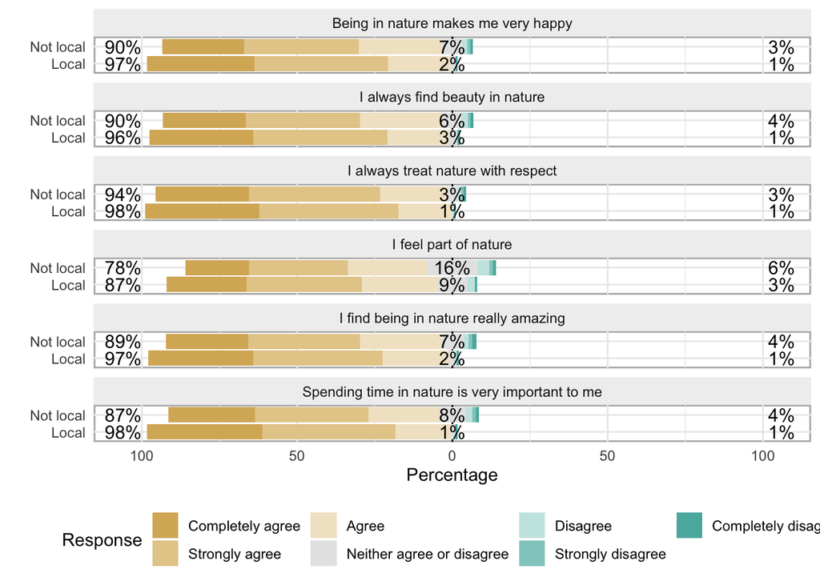

### Q20) In relation to the UK, how concerned are you about:

- Damage to the natural environment
- The consequences of a loss of variety of wildlife

[options] Not at all concerned = 1, Not very concerned = 2, Neither concerned or unconcerned = 3, Concerned = 4, Extremely concerned = 5

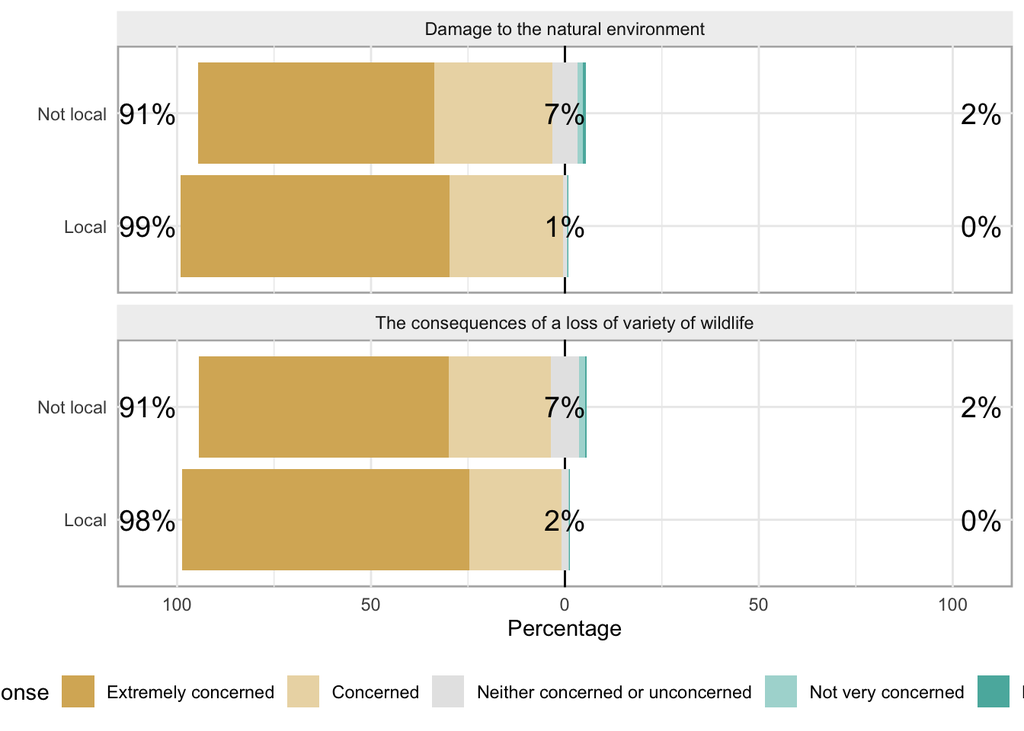

### Q21) How often do you do the actions below when you have the opportunity?

- When I see litter, I pick it up.
- I vote for nature or wildlife conservation friendly legislation in local or national referendums/votes/etc.
- I get in touch with local authorities on nature conservation issues.
- I vote for parties/ candidates with strong pro-nature conservation policies in elections.

[Options] Never = 1, Rarely = 2, Occasionally = 3, Sometimes = 4, Frequently = 5, Very frequently = 6, Always = 7

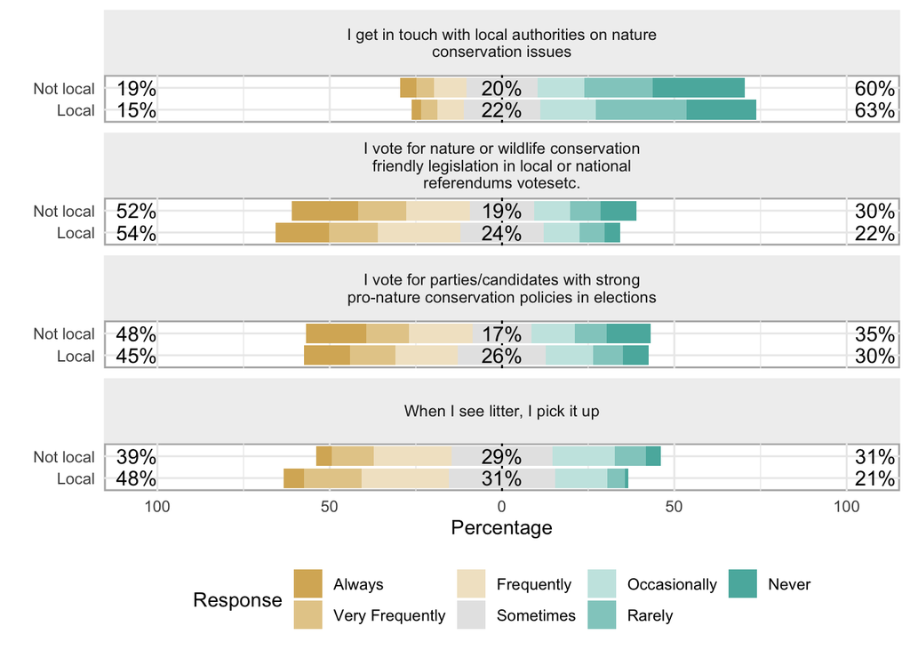

### Q23) Thinking about your daily life, how much do you agree or disagree with the following statements?

- I pay attention to birds wherever I go.
- I can identify common birds in my area.
- Seeing a new bird fills me with excitement.
- I am not interested in birds.

[Options] Strongly Disagree = 1, Disagree = 2, Neutral = 3, Agree = 4, Strongly Agree = 5. [†reverse scored]

```
## [1] "Q23.1..I.pay.attention.to.birds.wherever.I.go."
## [2] "Q23.2..I.can.identify.common.birds.in.my.area."
## [3] "Q23.3..Seeing.a.new.bird.fills.me.with.excitement."
## [4] "Q23.4..I.am.not.interested.in.birds."
## [5] "SurveyType"
## [6] "SiteLocal"
```

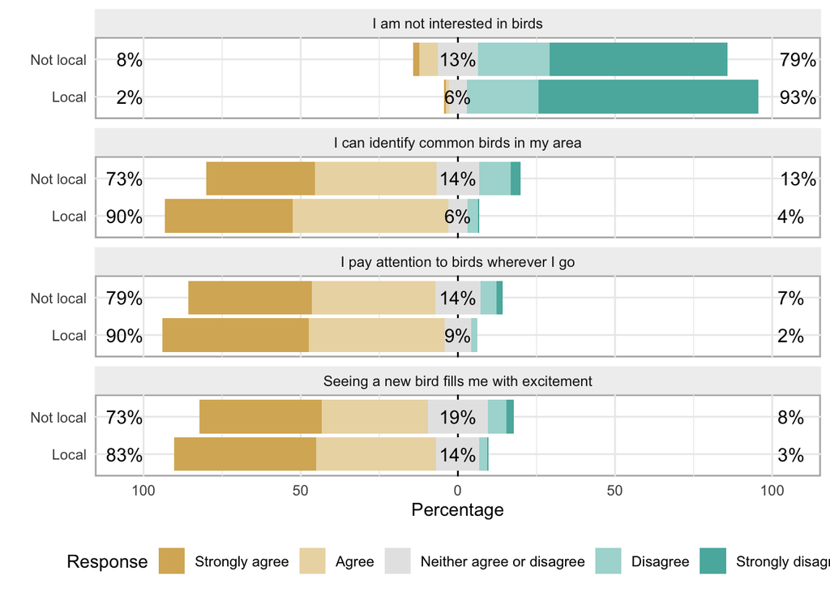

### Respondent scores

Creating summaries (mean values and sample size) for each of the scored questions (e.g. Attitude score, NCI etc.) which are then grouped by Survey Type and Proximity to release sites (SiteProximity).

```r
### Calculating mean values per group for each of the score columns
score_data <- final_data %>%
  select(UniqueID_all, SiteProximity, SurveyType,
         OverallAttitudeScore, KnowledgeScore, NCI,
         ProCoBS, BirdInterestScore, EnvConcern.score)
# Select all score vars
score_data %>%
  dplyr::group_by(SiteProximity, SurveyType) %>%
  summarise_at(vars(-UniqueID_all), funs(mean(., na.rm=TRUE)))
```

```
## # A tibble: 4 x 8
## # Groups:   SiteProximity [2]
##   SiteProximity SurveyType OverallAttitudeScore KnowledgeScore   NCI ProCoBS
##   <fct>         <fct>                     <dbl>          <dbl> <dbl>   <dbl>
## 1 No            NatRep                     3.82           2.28  46.8    12.6
## 2 No            Proactive                  4.32           4.39  66.2    18.4
## 3 Yes           NatRep                     3.77           1.77  45.9    13.4
## 4 Yes           Proactive                  4.29           4.00  65.6    16.4
## # … with 2 more variables: BirdInterestScore <dbl>, EnvConcern.score <dbl>
```

```r
# Count number of Non-NA values per column
score_data %>%
  dplyr::group_by(SiteProximity, SurveyType) %>%
    summarise_all(funs(count = sum(!is.na(.))))
```

```
## # A tibble: 4 x 9
## # Groups:   SiteProximity [2]
##   SiteProximity SurveyType UniqueID_all_cou… OverallAttitudeSc… KnowledgeScore_…
##   <fct>         <fct>                  <int>              <int>            <int>
## 1 No            NatRep                  1125                730             1125
## 2 No            Proactive               1374               1035             1374
## 3 Yes           NatRep                    18                 13               18
## 4 Yes           Proactive               1014                714             1014
## # … with 4 more variables: NCI_count <int>, ProCoBS_count <int>,
## #   BirdInterestScore_count <int>, EnvConcern.score_count <int>
```

#### Two-way ANOVA tests

Two-way ANOVA test is used to evaluate simultaneously the effect of two grouping variables (A and B) on a response variable.

**Two-way ANOVA test hypotheses**

- There is no difference in the means of factor A
- There is no difference in means of factor B
- There is no interaction between factors A and B
- The alternative hypothesis for cases 1 and 2 is: the means are not equal.

The alternative hypothesis for case 3 is: there is an interaction between A and B.

**Assumptions of two-way ANOVA test** Two-way ANOVA, like all ANOVA tests, assumes that the observations within each cell are normally distributed and have equal variances.

```r
### Testing for a significant difference in scores between groups
score_df <- final_data %>%
  select(UniqueID_all, SiteProximity, SurveyType,
         OverallAttitudeScore, KnowledgeScore, NCI,
         ProCoBS, BirdInterestScore, EnvConcern.score) %>%
  drop_na()
# Generate frequency tables (sample size per group):
table(score_df$SurveyType, score_df$SiteProximity)
```

```
##
##               No  Yes
##   NatRep     727   13
##   Proactive 1032  711
```

```r
### Check assumptions
## Normality using Shapiro
score_data %>%
  dplyr::group_by(SiteProximity, SurveyType) %>%
  rstatix::shapiro_test(OverallAttitudeScore, KnowledgeScore, NCI,
         ProCoBS, BirdInterestScore, EnvConcern.score)
```

```
## # A tibble: 24 x 5
##    SiteProximity SurveyType variable             statistic        p
##    <fct>         <fct>      <chr>                    <dbl>    <dbl>
##  1 No            NatRep     BirdInterestScore        0.971 3.50e-14
##  2 No            NatRep     EnvConcern.score         0.855 5.90e-31
##  3 No            NatRep     KnowledgeScore           0.974 2.03e-13
##  4 No            NatRep     NCI                      0.920 6.80e-24
##  5 No            NatRep     OverallAttitudeScore     0.973 2.93e-10
##  6 No            NatRep     ProCoBS                  0.967 3.41e-15
##  7 No            Proactive  BirdInterestScore        0.799 3.26e-38
##  8 No            Proactive  EnvConcern.score         0.484 1.07e-52
##  9 No            Proactive  KnowledgeScore           0.958 2.21e-19
## 10 No            Proactive  NCI                      0.904 1.74e-28
## # … with 14 more rows
```

```r
# Checking for factor columns
# str(score_df) # Need to convert site proximity from char to Factor and rename levels
score_df$SiteProximity <- as.factor(score_df$SiteProximity)
score_df$SiteProximity <- dplyr::recode_factor(score_df$SiteProximity, 'Yes' = "Local", 'No' = "NotLocal")
```

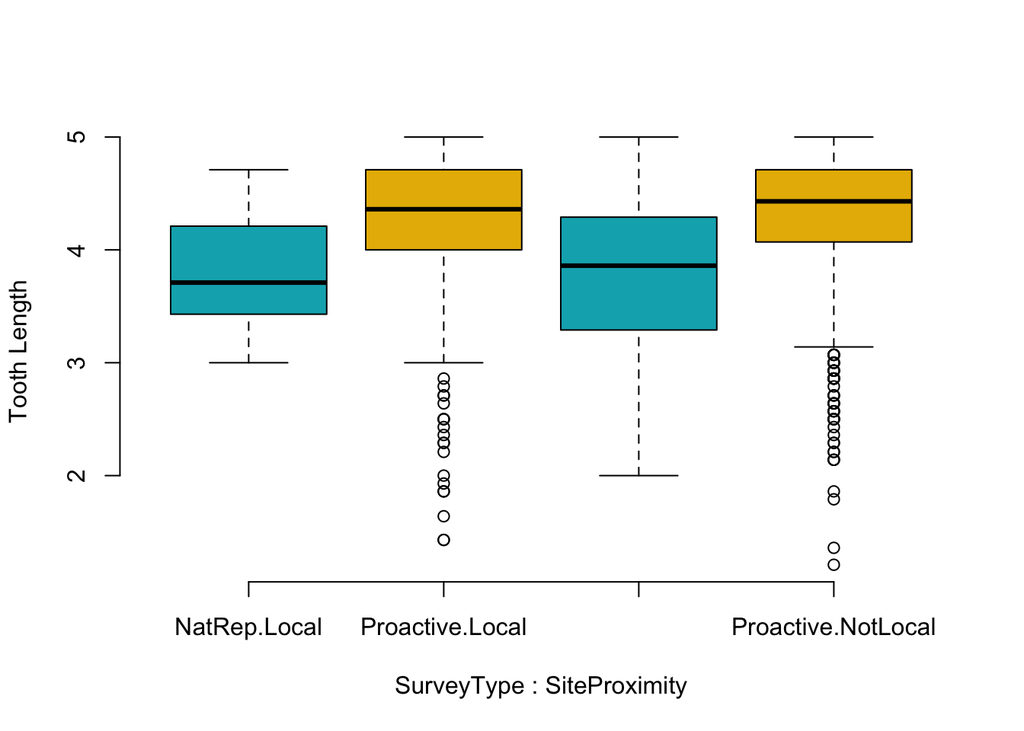

```r
# Box plot with two factor variables
boxplot(OverallAttitudeScore ~ SurveyType * SiteProximity, data=score_df, frame = FALSE,
        col = c("#00AFBB", "#E7B800"), ylab="Tooth Length")
```

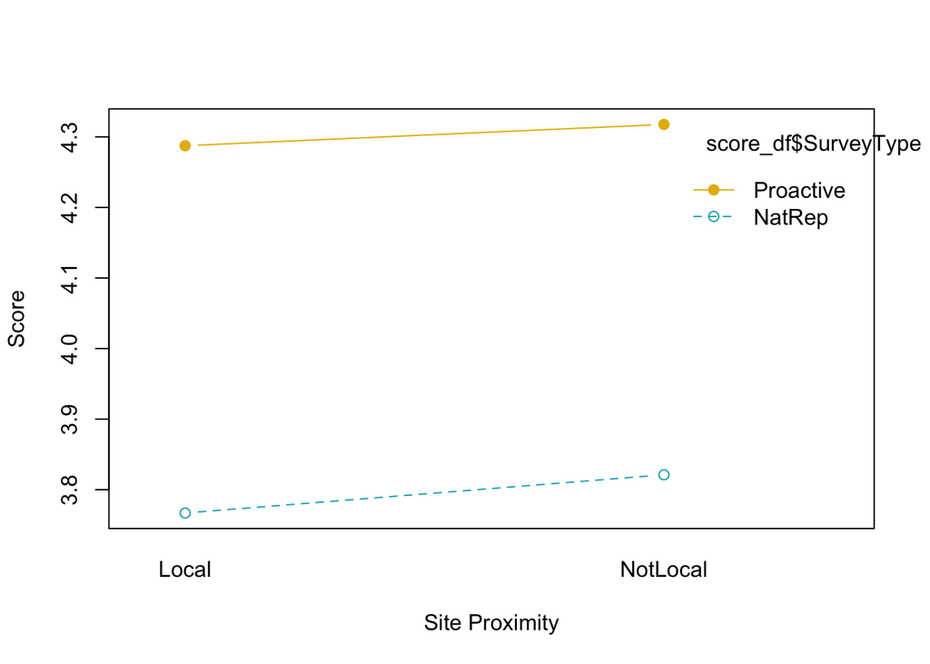

```r
# Two-way interaction plot
interaction.plot(x.factor = score_df$SiteProximity, trace.factor = score_df$SurveyType,
                 response = score_df$OverallAttitudeScore, fun = mean,
                 type = "b", legend = TRUE,
                 xlab = "Site Proximity", ylab="Score",
                 pch=c(1,19), col = c("#00AFBB", "#E7B800"))
```

```r
### Compute 2-way ANOVAs per score variable (interaction)
# OverallAttitudeScore
attitude.aov2 <- aov(OverallAttitudeScore ~ SurveyType * SiteProximity, data = score_df)
summary(attitude.aov2)
```

```
##                            Df Sum Sq Mean Sq F value Pr(>F)
## SurveyType                  1  122.3  122.29 342.961 <2e-16 ***
## SiteProximity               1    0.4    0.41   1.158  0.282
## SurveyType:SiteProximity    1    0.0    0.01   0.020  0.887
## Residuals                2479  883.9    0.36
## ---
## Signif. codes:  0 '***' 0.001 '**' 0.01 '*' 0.05 '.' 0.1 ' ' 1
```

```r
# KnowledgeScore
knowl.aov2 <- aov(KnowledgeScore ~ SurveyType * SiteProximity, data = score_df)
summary(knowl.aov2)
```

```
##                            Df Sum Sq Mean Sq  F value  Pr(>F)
## SurveyType                  1   2134  2133.8 1009.680 < 2e-16 ***
## SiteProximity               1     57    57.3   27.093 2.1e-07 ***
## SurveyType:SiteProximity    1      1     1.2    0.555   0.456
## Residuals                2479   5239     2.1
## ---
## Signif. codes:  0 '***' 0.001 '**' 0.01 '*' 0.05 '.' 0.1 ' ' 1
```

```r
# NCI
nci.aov2 <- aov(NCI ~ SurveyType * SiteProximity, data = score_df)
summary(nci.aov2)
```

```
##                            Df  Sum Sq Mean Sq F value Pr(>F)
## SurveyType                  1  189365  189365 327.792 <2e-16 ***
## SiteProximity               1     662     662   1.145  0.285
## SurveyType:SiteProximity    1     276     276   0.479  0.489
## Residuals                2479 1432116     578
## ---
## Signif. codes:  0 '***' 0.001 '**' 0.01 '*' 0.05 '.' 0.1 ' ' 1
```

```r
# ProCoBS
ProCoBS.aov2 <- aov(ProCoBS ~ SurveyType * SiteProximity, data = score_df)
summary(ProCoBS.aov2)
```

```
##                            Df Sum Sq Mean Sq F value Pr(>F)
## SurveyType                  1  11578   11578 489.589 <2e-16 ***
## SiteProximity               1   1826    1826  77.192 <2e-16 ***
## SurveyType:SiteProximity    1    145     145   6.134 0.0133 *
## Residuals                2479  58627      24
## ---
## Signif. codes:  0 '***' 0.001 '**' 0.01 '*' 0.05 '.' 0.1 ' ' 1
```

```r
# BirdInterestScore
bis.aov2 <- aov(BirdInterestScore ~ SurveyType * SiteProximity, data = score_df)
summary(bis.aov2)
```

```
##                            Df Sum Sq Mean Sq F value   Pr(>F)
## SurveyType                  1   5377    5377 789.943  < 2e-16 ***
## SiteProximity               1     82      82  12.042 0.000529 ***
## SurveyType:SiteProximity    1      8       8   1.209 0.271657
## Residuals                2479  16873       7
## ---
## Signif. codes:  0 '***' 0.001 '**' 0.01 '*' 0.05 '.' 0.1 ' ' 1
```

```r
# EnvConcern.score
env.aov2 <- aov(EnvConcern.score ~ SurveyType * SiteProximity, data = score_df)
summary(env.aov2)
```

```
##                            Df Sum Sq Mean Sq F value   Pr(>F)
## SurveyType                  1  908.5   908.5 713.213  < 2e-16 ***
## SiteProximity               1   26.2    26.2  20.604 5.92e-06 ***
## SurveyType:SiteProximity    1   10.5    10.5   8.281  0.00404 **
## Residuals                2479 3157.6     1.3
## ---
## Signif. codes:  0 '***' 0.001 '**' 0.01 '*' 0.05 '.' 0.1 ' ' 1
```

[^1]: University of Brighton, l.jones4@brighton.ac.uk